# Birth Volume and Cesarean Delivery Rates in Brazil — analyses of the main text

Revised manuscript IJG-D-26-02002: Tables 1–3, Figures 1–3 and numbers reported in the Abstract and Results

## Packages and helpers

```r
library(readr); library(dplyr); library(tidyr); library(ggplot2); library(cowplot); library(lme4); library(knitr)
fmt  <- function(x, d = 1) formatC(x, format = "f", digits = d, big.mark = ",")
n_   <- function(x) formatC(x, format = "d", big.mark = ",")
q_   <- function(x, p) as.numeric(quantile(x, p))
miqr <- function(x, d = 1) sprintf("%s (%s–%s)", fmt(median(x), d), fmt(q_(x, .25), d), fmt(q_(x, .75), d))
pval <- function(p) ifelse(p < 0.001, "<0.001", sprintf("%.3f", p))
NAVY <- "#1f3864"; BLUE <- "#2e75b6"; ORG <- "#c55a11"
tema <- theme_classic(base_size = 11) +
  theme(panel.grid.major.y = element_line(colour = "#eeeeee"),
        plot.title = element_text(colour = NAVY, hjust = 0.5, size = 11), axis.text = element_text(colour = "black"))
```

## Data

`data/facility_years.csv` has one row per facility-year with at least one live birth in the study years 2018, 2019, 2022, 2023 and 2024. The main analysis uses the 12,476 eligible facility-years (`eligible`: at least 100 live births), of which the 12,104 with complete covariate data (`included_main_model`) enter the model. Variables: `live_births` and `cesareans` (SINASC); `beds` (funding source derived from CNES beds: SUS = public, Misto = mixed, Privado = private); `high_risk` (CNES high-risk pregnancy accreditation, Yes/No); `typology` (IBGE rural–urban typology: Rural, Intermediario, Urbano); `hdi_state` (state HDI of the year); `pct_black_brown` and `pct_previous_cesarean` (facility-level proportions, %).

```r
BANDS <- c("100 - 499", "500 - 999", "1000 - 1499", "1500 - 1999", ">1999")
eleg <- read_csv("data/facility_years.csv", col_types = cols(cnes = "c", cod_mun = "c")) |>
  filter(eligible) |>
  mutate(included = included_main_model,
         volume_band = as.character(cut(live_births, c(100, 500, 1000, 1500, 2000, Inf), right = FALSE, labels = BANDS)))
stopifnot(nrow(eleg) == 12476)
BLAB  <- c("100–499", "500–999", "1000–1499", "1500–1999", "≥2000")
COMB  <- c("SUS No" = "Public (SUS), not accredited", "SUS Yes" = "Public (SUS), accredited",
           "Misto No" = "Mixed, not accredited", "Misto Yes" = "Mixed, accredited", "Privado No" = "Private, not accredited")
TYP   <- c("Rural" = "Rural", "Intermediario" = "Intermediate", "Urbano" = "Urban")
d <- eleg |> filter(included) |>
  mutate(rate = 100 * cesareans / live_births,
         band = factor(volume_band, BANDS, BLAB),
         comb = factor(COMB[paste(beds, high_risk)], COMB),
         typ  = factor(TYP[typology], TYP))
stopifnot(nrow(d) == 12104, !anyNA(d$comb), !anyNA(d$band), !anyNA(d$typ))
```

## Study sample (Results, first paragraph; Supplementary Figure S1)

```r
excl <- eleg |> filter(!included)
tibble(
  `Eligible facility-years (≥100 live births)` = n_(nrow(eleg)),
  `Excluded, missing covariate data` = n_(nrow(excl)),
  `  of which without registered beds (funding source)` = n_(sum(is.na(excl$beds))),
  `  of which without case-mix data` = n_(sum(!is.na(excl$beds))),
  `Included facility-years` = n_(nrow(d)),
  `Distinct facilities` = n_(n_distinct(d$cnes)),
  `Facilities present in all five years` = n_(sum(table(d$cnes) == 5)),
  `Live births` = n_(sum(d$live_births)),
  `Excluded: birth-weighted cesarean rate, %` = fmt(100 * sum(excl$cesareans) / sum(excl$live_births)),
  `Excluded: facility-years with 100–499 births` = n_(sum(excl$volume_band == "100 - 499"))
) |> pivot_longer(everything(), names_to = "Item", values_to = "Value") |> kable()
```

| Item | Value |
| --- | --- |
| Eligible facility-years (≥100 live births) | 12,476 |
| Excluded, missing covariate data | 372 |
| of which without registered beds (funding source) | 292 |
| of which without case-mix data | 80 |
| Included facility-years | 12,104 |
| Distinct facilities | 2,940 |
| Facilities present in all five years | 1,917 |
| Live births | 12,650,487 |
| Excluded: birth-weighted cesarean rate, % | 74.7 |
| Excluded: facility-years with 100–499 births | 233 |

## Table 1. Characteristics of the included facility-years

```r
tot_b <- sum(d$live_births)
cat_n <- function(v) d |> count(g = .data[[v]]) |> mutate(val = sprintf("%s (%s)", n_(n), fmt(100 * n / nrow(d))))
t1 <- bind_rows(
  tibble(Characteristic = c("Facility-years, n", "Distinct facilities, n", "Live births, n",
                            "Cesarean rate, unweighted facility mean (SD), %", "Cesarean rate, birth-weighted, %",
                            "Annual live births, median (IQR)"),
         Value = c(n_(nrow(d)), n_(n_distinct(d$cnes)), n_(tot_b),
                   sprintf("%s (%s)", fmt(mean(d$rate)), fmt(sd(d$rate))),
                   fmt(100 * sum(d$cesareans) / tot_b),
                   sprintf("%s (%s–%s)", n_(median(d$live_births)), n_(q_(d$live_births, .25)), n_(q_(d$live_births, .75))))),
  tibble(Characteristic = "Annual live births, n (%) of facility-years / % of births", Value = ""),
  d |> group_by(band) |> summarise(n = n(), b = sum(live_births)) |>
    transmute(Characteristic = paste0("    ", band), Value = sprintf("%s (%s) / %s", n_(n), fmt(100 * n / nrow(d)), fmt(100 * b / tot_b))),
  tibble(Characteristic = "Facility type × high-risk accreditation, n (%)", Value = ""),
  cat_n("comb") |> transmute(Characteristic = paste0("    ", g), Value = val),
  tibble(Characteristic = "Municipal typology, n (%)", Value = ""),
  cat_n("typ") |> transmute(Characteristic = paste0("    ", g), Value = val),
  tibble(Characteristic = "State HDI, median (IQR)", Value = miqr(d$hdi_state, 3)),
  tibble(Characteristic = "Facility-level case mix, median (IQR)", Value = ""),
  tibble(Characteristic = c("    Mothers with a previous cesarean, %", "    Black or brown mothers, %"),
         Value = c(miqr(d$pct_previous_cesarean), miqr(d$pct_black_brown))))
kable(t1)
```

| Characteristic | Value |
| --- | --- |
| Facility-years, n | 12,104 |
| Distinct facilities, n | 2,940 |
| Live births, n | 12,650,487 |
| Cesarean rate, unweighted facility mean (SD), % | 63.5 (25.3) |
| Cesarean rate, birth-weighted, % | 58.4 |
| Annual live births, median (IQR) | 517 (227–1,371) |
| Annual live births, n (%) of facility-years / % of births |  |
| 100–499 | 5,928 (49.0) / 11.6 |
| 500–999 | 2,242 (18.5) / 12.6 |
| 1000–1499 | 1,182 (9.8) / 11.6 |
| 1500–1999 | 808 (6.7) / 11.1 |
| ≥2000 | 1,944 (16.1) / 53.1 |
| Facility type × high-risk accreditation, n (%) |  |
| Public (SUS), not accredited | 3,895 (32.2) |
| Public (SUS), accredited | 326 (2.7) |
| Mixed, not accredited | 5,134 (42.4) |
| Mixed, accredited | 727 (6.0) |
| Private, not accredited | 2,022 (16.7) |
| Municipal typology, n (%) |  |
| Rural | 1,942 (16.0) |
| Intermediate | 1,515 (12.5) |
| Urban | 8,647 (71.4) |
| State HDI, median (IQR) | 0.787 (0.750–0.812) |
| Facility-level case mix, median (IQR) |  |
| Mothers with a previous cesarean, % | 32.4 (24.6–39.7) |
| Black or brown mothers, % | 68.8 (38.2–89.2) |

## Table 2. Cesarean rates by facility and regional characteristics

Continuous covariates are shown by quartiles of their distribution across the included facility-years.

```r
t2row <- function(g, data = d) data |> group_by(g = {{ g }}) |>
  summarise(`Facility-years, n` = n_(n()), `Median (IQR), %` = miqr(rate),
            `Birth-weighted, %` = fmt(100 * sum(cesareans) / sum(live_births)), .groups = "drop")
quart <- function(v, dig) {
  k <- q_(d[[v]], c(.25, .5, .75)); g <- cut(d[[v]], c(-Inf, k, Inf), labels = paste0("Q", 1:4))
  rg <- tapply(d[[v]], g, function(z) sprintf("(%s–%s)", fmt(min(z), dig), fmt(max(z), dig)))
  t2row(gq, data = d |> mutate(gq = factor(paste(g, rg[as.character(g)]))))
}
blk <- function(title, x) bind_rows(tibble(g = title), x |> mutate(g = paste0("    ", g)))
t2 <- bind_rows(blk("Annual live births", t2row(band)),
                blk("Facility type × high-risk accreditation", t2row(comb)),
                blk("Municipal typology", t2row(typ)),
                blk("State HDI (quartiles)", quart("hdi_state", 3)),
                blk("Mothers with a previous cesarean, % (quartiles)", quart("pct_previous_cesarean", 1)),
                blk("Black or brown mothers, % (quartiles)", quart("pct_black_brown", 1))) |>
  rename(Characteristic = g) |> mutate(across(everything(), ~ replace_na(.x, "")))
kable(t2)
```

| Characteristic | Facility-years, n | Median (IQR), % | Birth-weighted, % |
| --- | --- | --- | --- |
| Annual live births |  |  |  |
| 100–499 | 5,928 | 73.9 (49.4–91.0) | 67.1 |
| 500–999 | 2,242 | 69.1 (52.2–84.3) | 66.8 |
| 1000–1499 | 1,182 | 61.6 (47.6–79.2) | 62.4 |
| 1500–1999 | 808 | 60.0 (47.2–74.8) | 60.7 |
| ≥2000 | 1,944 | 51.3 (40.5–65.0) | 53.3 |
| Facility type × high-risk accreditation |  |  |  |
| Public (SUS), not accredited | 3,895 | 48.4 (30.6–66.1) | 46.2 |
| Public (SUS), accredited | 326 | 47.1 (39.4–57.0) | 47.2 |
| Mixed, not accredited | 5,134 | 70.1 (54.4–85.1) | 60.0 |
| Mixed, accredited | 727 | 55.5 (46.8–65.2) | 54.4 |
| Private, not accredited | 2,022 | 90.3 (83.1–95.9) | 81.7 |
| Municipal typology |  |  |  |
| Rural | 1,942 | 54.3 (30.5–73.4) | 51.3 |
| Intermediate | 1,515 | 60.4 (41.1–78.4) | 55.7 |
| Urban | 8,647 | 69.8 (50.5–87.4) | 58.9 |
| State HDI (quartiles) |  |  |  |
| Q1 (0.693–0.748) | 3,026 | 49.8 (30.3–69.5) | 52.5 |
| Q2 (0.751–0.787) | 3,090 | 65.4 (48.3–85.3) | 59.8 |
| Q3 (0.788–0.812) | 3,009 | 73.2 (56.4–88.1) | 61.3 |
| Q4 (0.813–0.870) | 2,979 | 73.4 (53.4–86.4) | 59.9 |
| Mothers with a previous cesarean, % (quartiles) |  |  |  |
| Q1 (0.0–24.6) | 3,026 | 36.1 (23.4–46.4) | 38.7 |
| Q2 (24.6–32.4) | 3,026 | 57.9 (49.5–67.9) | 56.5 |
| Q3 (32.4–39.7) | 3,026 | 76.2 (66.6–86.1) | 73.5 |
| Q4 (39.7–100.0) | 3,026 | 90.8 (81.3–96.3) | 80.3 |
| Black or brown mothers, % (quartiles) |  |  |  |
| Q1 (0.0–38.2) | 3,026 | 78.0 (62.4–89.1) | 68.4 |
| Q2 (38.2–68.8) | 3,026 | 77.4 (60.4–90.4) | 64.9 |
| Q3 (68.8–89.2) | 3,026 | 58.2 (42.2–78.9) | 51.3 |
| Q4 (89.2–100.0) | 3,026 | 49.2 (32.3–63.5) | 51.6 |

## Other descriptive results reported in the text

```r
hab <- d |> filter(high_risk == "Yes")
tibble(
  `Facility-years with <500 births, %` = fmt(100 * mean(d$live_births < 500)),
  `Accredited facility-years, n` = n_(nrow(hab)),
  `Accredited: public (SUS), %` = fmt(100 * mean(hab$beds == "SUS")),
  `Accredited: mixed, %` = fmt(100 * mean(hab$beds == "Misto")),
  `Accredited: private, n` = n_(sum(hab$beds == "Privado")),
  `Accredited with ≥2000 births, %` = fmt(100 * mean(hab$volume_band == ">1999")),
  `Accredited with <500 births, n` = n_(sum(hab$live_births < 500))
) |> pivot_longer(everything(), names_to = "Item", values_to = "Value") |> kable()
```

| Item | Value |
| --- | --- |
| Facility-years with <500 births, % | 49.0 |
| Accredited facility-years, n | 1,053 |
| Accredited: public (SUS), % | 31.0 |
| Accredited: mixed, % | 69.0 |
| Accredited: private, n | 0 |
| Accredited with ≥2000 births, % | 69.4 |
| Accredited with <500 births, n | 3 |

## Figure 1. Cesarean rate by year

```r
por_ano <- d |> group_by(year) |>
  summarise(`Birth-weighted rate` = 100 * sum(cesareans) / sum(live_births),
            `Unweighted mean of facility-level rates` = mean(rate), .groups = "drop")
kable(por_ano |> mutate(across(-year, ~ fmt(.x))))
```

| year | Birth-weighted rate | Unweighted mean of facility-level rates |
| --- | --- | --- |
| 2018 | 56.2 | 60.7 |
| 2019 | 56.7 | 61.1 |
| 2022 | 58.7 | 63.9 |
| 2023 | 60.2 | 65.7 |
| 2024 | 61.2 | 66.9 |

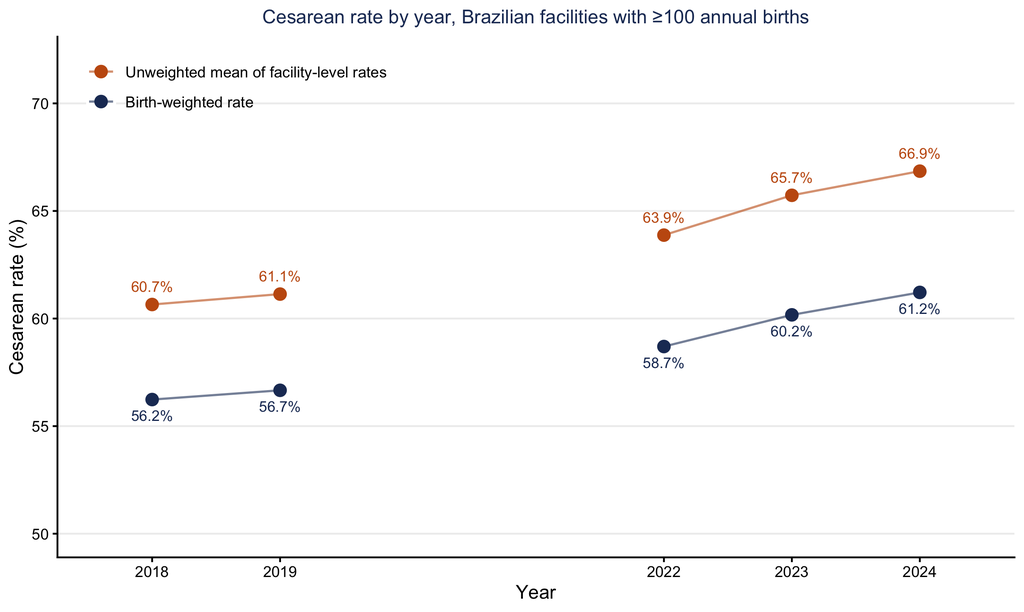

```r
pa <- por_ano |> pivot_longer(-year, names_to = "taxa", values_to = "valor") |>
  mutate(taxa = factor(taxa, c("Unweighted mean of facility-level rates", "Birth-weighted rate")),
         seg = ifelse(year <= 2019, "a", "b"), vj = ifelse(taxa == "Birth-weighted rate", 2.0, -1.2))
ggplot(pa, aes(year, valor, colour = taxa)) +
  geom_line(aes(group = interaction(taxa, seg)), alpha = 0.6, linewidth = 0.6) + geom_point(size = 3) +
  geom_text(aes(label = sprintf("%.1f%%", valor), vjust = vj), size = 3, show.legend = FALSE) +
  scale_colour_manual(values = c(ORG, NAVY), name = NULL) +
  scale_x_continuous(breaks = unique(pa$year), limits = c(2017.6, 2024.4)) +
  scale_y_continuous(limits = c(50, 72), breaks = seq(50, 70, 5)) +
  labs(x = "Year", y = "Cesarean rate (%)", title = "Cesarean rate by year, Brazilian facilities with ≥100 annual births") +
  tema + theme(legend.position = c(0.02, 0.98), legend.justification = c(0, 1), legend.background = element_blank())
```

## Figure 2. Facility-level cesarean rates by characteristics

Boxes show the median and interquartile range; whiskers extend to the most extreme values within 1.5×IQR; points beyond the whiskers are outlying facility-years.

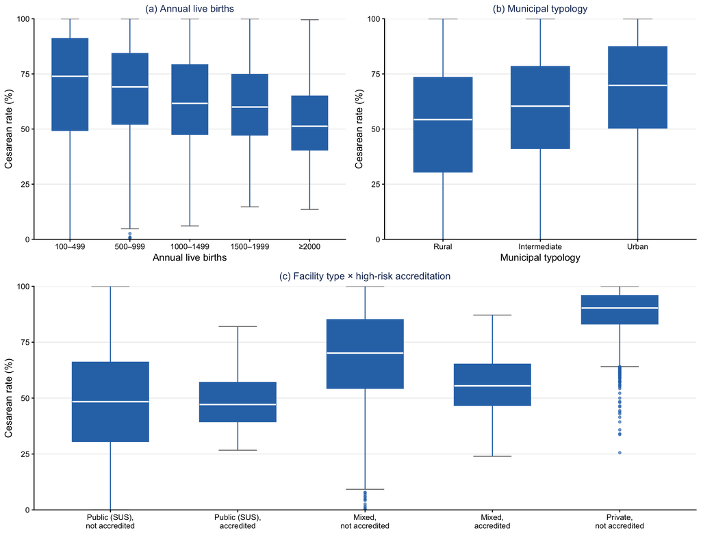

```r
caixa <- function(g, titulo, xlab = NULL)
  ggplot(d, aes({{ g }}, rate)) +
    stat_boxplot(geom = "errorbar", width = 0.3, colour = "grey50", coef = 1.5) +
    geom_boxplot(fill = BLUE, colour = BLUE, width = 0.6, outlier.size = 1.1, outlier.alpha = 0.6, outlier.colour = BLUE, coef = 1.5, median.colour = "white", median.linewidth = 0.8) +
    scale_y_continuous(limits = c(0, 100), expand = c(0, 0)) + labs(x = xlab, y = "Cesarean rate (%)", title = titulo) + tema
lab_comb <- setNames(sub(", ", ",\n", COMB), COMB)
plot_grid(plot_grid(caixa(band, "(a) Annual live births", "Annual live births"),
                    caixa(typ, "(b) Municipal typology", "Municipal typology"), ncol = 2, align = "h", axis = "bt"),
          caixa(comb, "(c) Facility type × high-risk accreditation") + scale_x_discrete(labels = lab_comb), ncol = 1)
```

## Table 3. Multilevel binomial model (model 2.6)

Facility-level cesarean counts with total live births as the denominator; logit link; random intercepts for municipality and state and an observation-level (facility-year) random effect for overdispersion. Reference categories: public (SUS) facilities without high-risk accreditation, ≥2000 annual births and rural municipality. HDI on its natural scale (odds ratio reported per 0.1 unit); facility proportions per one percentage point.

```r
dm <- d |> mutate(comb = relevel(comb, ref = "Public (SUS), not accredited"),
                  band = relevel(factor(band, BLAB), ref = "≥2000"),
                  typ  = relevel(typ, ref = "Rural"), obs = factor(row_number()))
ctrl <- glmerControl(optimizer = "bobyqa", optCtrl = list(maxfun = 2e5))
m26 <- glmer(cbind(cesareans, live_births - cesareans) ~ comb + band + typ + hdi_state + pct_black_brown +
               pct_previous_cesarean + (1 | cod_mun) + (1 | uf) + (1 | obs),
             data = dm, family = binomial, control = ctrl)
cat("Observations:", nobs(m26), "| convergence:",
    if (is.null(m26@optinfo$conv$lme4$messages)) "OK" else paste(m26@optinfo$conv$lme4$messages, collapse = "; "),
    "| residual dispersion:", round(sum(residuals(m26, type = "pearson")^2) / df.residual(m26), 2), "\n")
```

```
## Observations: 12104 | convergence: OK | residual dispersion: 0.15
```

```r
co <- summary(m26)$coefficients
or_tab <- function(co, escala = c(hdi_state = 0.1), dig_pp = 3) {
  tibble(term = rownames(co), b = co[, 1], se = co[, 2], p = co[, 4]) |> filter(term != "(Intercept)") |>
    mutate(k = ifelse(term %in% names(escala), escala[term], 1),
           dig = ifelse(grepl("^pct_", term), dig_pp, 2),
           OR = exp(b * k), lo = exp((b - 1.96 * se) * k), hi = exp((b + 1.96 * se) * k),
           `OR` = mapply(fmt, OR, dig), `95% CI` = paste0(mapply(fmt, lo, dig), "–", mapply(fmt, hi, dig)),
           `p-value` = pval(p)) |> select(term, `OR`, `95% CI`, `p-value`)
}
t3 <- or_tab(co) |> mutate(term = term |> sub("^comb", "", x = _) |> sub("^band", "Annual live births ", x = _) |>
                              sub("^typ", "Municipal typology: ", x = _) |>
                              recode(hdi_state = "State HDI (per 0.1)",
                                     pct_previous_cesarean = "Mothers with a previous cesarean, % (per 1 percentage point)",
                                     pct_black_brown = "Black or brown mothers, % (per 1 percentage point)"))
kable(t3, col.names = c("Predictor", "OR", "95% CI", "p-value"))
```

| Predictor | OR | 95% CI | p-value |
| --- | --- | --- | --- |
| Public (SUS), accredited | 1.61 | 1.46–1.76 | <0.001 |
| Mixed, not accredited | 1.87 | 1.78–1.98 | <0.001 |
| Mixed, accredited | 1.58 | 1.46–1.71 | <0.001 |
| Private, not accredited | 3.94 | 3.69–4.21 | <0.001 |
| Annual live births 100–499 | 2.12 | 1.99–2.25 | <0.001 |
| Annual live births 500–999 | 1.65 | 1.55–1.75 | <0.001 |
| Annual live births 1000–1499 | 1.33 | 1.25–1.42 | <0.001 |
| Annual live births 1500–1999 | 1.15 | 1.08–1.23 | <0.001 |
| Municipal typology: Intermediate | 1.10 | 0.93–1.30 | 0.263 |
| Municipal typology: Urban | 1.62 | 1.40–1.87 | <0.001 |
| State HDI (per 0.1) | 1.71 | 1.54–1.89 | <0.001 |
| Black or brown mothers, % (per 1 percentage point) | 0.988 | 0.987–0.989 | <0.001 |
| Mothers with a previous cesarean, % (per 1 percentage point) | 1.057 | 1.055–1.059 | <0.001 |

## Secondary analysis: annual volume as a continuous exposure (log2)

```r
m_log2 <- update(m26, . ~ . - band + log2(live_births))
c2 <- summary(m_log2)$coefficients["log2(live_births)", ]
cat(sprintf("OR per doubling of annual volume: %.2f (95%% CI %.2f–%.2f); convergence: %s\n",
            exp(c2[1]), exp(c2[1] - 1.96 * c2[2]), exp(c2[1] + 1.96 * c2[2]),
            if (is.null(m_log2@optinfo$conv$lme4$messages)) "OK" else "warning"))
```

```
## OR per doubling of annual volume: 0.84 (95% CI 0.82–0.85); convergence: OK
```

## Figure 3. Adjusted odds ratios

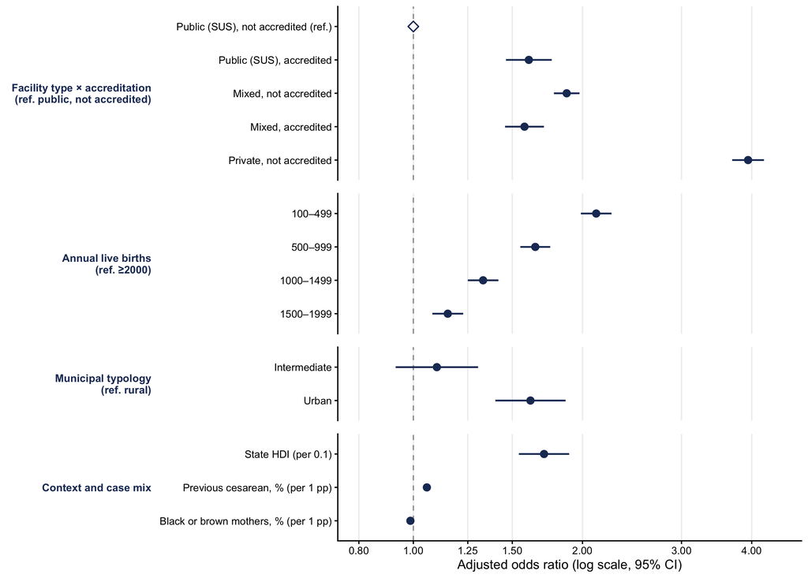

```r
GR <- c("Facility type × accreditation\n(ref. public, not accredited)", "Annual live births\n(ref. ≥2000)",
        "Municipal typology\n(ref. rural)", "Context and case mix")
f3 <- tibble(term = rownames(co), b = co[, 1], se = co[, 2]) |> filter(term != "(Intercept)") |>
  mutate(k = ifelse(term == "hdi_state", 0.1, 1), OR = exp(b * k), lo = exp((b - 1.96 * se) * k), hi = exp((b + 1.96 * se) * k),
         grupo = case_when(grepl("^comb", term) ~ GR[1], grepl("^band", term) ~ GR[2], grepl("^typ", term) ~ GR[3], TRUE ~ GR[4]),
         rotulo = term |> sub("^comb|^band|^typ", "", x = _) |>
           recode(Intermediario = "Intermediate", Urbano = "Urban", hdi_state = "State HDI (per 0.1)",
                  pct_previous_cesarean = "Previous cesarean, % (per 1 pp)",
                  pct_black_brown = "Black or brown mothers, % (per 1 pp)")) |>
  bind_rows(tibble(term = "REF", OR = 1, grupo = GR[1], rotulo = "Public (SUS), not accredited (ref.)"))
ord <- c("Public (SUS), not accredited (ref.)", COMB[-1], BLAB[-5], "Intermediate", "Urban", "State HDI (per 0.1)",
         "Previous cesarean, % (per 1 pp)", "Black or brown mothers, % (per 1 pp)")
f3 <- f3 |> mutate(grupo = factor(grupo, GR), rotulo = factor(rotulo, rev(ord)))
stopifnot(!anyNA(f3$rotulo))
ggplot(f3, aes(OR, rotulo)) +
  geom_vline(xintercept = 1, linetype = "dashed", colour = "grey60") +
  geom_errorbar(aes(xmin = lo, xmax = hi), width = 0, orientation = "y", colour = NAVY, linewidth = 0.7, na.rm = TRUE) +
  geom_point(data = filter(f3, term != "REF"), colour = NAVY, size = 2.6) +
  geom_point(data = filter(f3, term == "REF"), shape = 23, fill = "white", colour = NAVY, size = 2.8, stroke = 0.8) +
  facet_grid(grupo ~ ., scales = "free_y", space = "free_y", switch = "y") +
  scale_x_log10(breaks = c(0.8, 1, 1.25, 1.5, 2, 3, 4), limits = c(0.8, 4.5)) +
  labs(x = "Adjusted odds ratio (log scale, 95% CI)", y = NULL) +
  tema + theme(strip.placement = "outside", strip.background = element_blank(),
               strip.text.y.left = element_text(angle = 0, hjust = 1, face = "bold", colour = NAVY, size = 9),
               panel.grid.major.y = element_blank(), panel.grid.major.x = element_line(colour = "#eeeeee"),
               panel.spacing.y = unit(4, "mm"))
```